# Random Forest

Shannon Kwok

2026-11-16

### Import packages

```r
library(dplyr)
library(readr)
library(tidyr)
library(ranger)
library(pROC)
library(knitr)
library(ggplot2)
set.seed(1213) # same seed as LASSO
```

## 1. Load data

```r
macro <- read_csv("../data/processed/fred_md_macro_clean_final.csv", show_col_types = FALSE)
macro_fin <- read_csv("../data/processed/fred_md_macro_financial_clean_final.csv", show_col_types = FALSE)

# Number of predictors (p) used to set mtry later
p_macro <- ncol(macro) - 2  # excludes sasdate and USREC
p_macro_fin <- ncol(macro_fin) - 2
c(p_macro = p_macro, p_macro_fin = p_macro_fin)
```

```
##     p_macro p_macro_fin
##          97         122
```

## 2. Target construction

Construct Y_3, Y_6 and Y_12 columns for 3, 6 and 12 month horizons.

```r
# Construct Y_3, Y_6, Y_12
create_targets <- function(df) {
  df <- df %>%
    arrange(sasdate)
  for (h in c(3, 6, 12)) {
    future_recession <- sapply(
      seq_len(nrow(df)),
      function(i) {
        future_rows <- (i + 1):(i + h)
        # Exclude observations without complete future data
        if (max(future_rows) > nrow(df)) {
          return(NA_integer_)
        }
        future_values <- df$USREC[future_rows]
        # Handle missing recession indicators
        if (any(is.na(future_values))) {
          return(NA_integer_)
        }

        # 1 if any future month is recessionary
        as.integer(any(future_values == 1))
      }
    )
    df[[paste0("Y_", h)]] <- future_recession
  }
  return(df)
}


macro <- create_targets(macro)
macro_fin <- create_targets(macro_fin)

# logic check using 2008 recession as example
macro %>%
  select(sasdate, USREC, Y_3, Y_6, Y_12) %>%
  filter(
    sasdate >= as.Date("2007-01-01"),
    sasdate <= as.Date("2008-06-01")
  ) %>%
  print(n = Inf)
```

```
## # A tibble: 18 × 5
##    sasdate    USREC   Y_3   Y_6  Y_12
##    <date>     <dbl> <int> <int> <int>
##  1 2007-01-01     0     0     0     1
##  2 2007-02-01     0     0     0     1
##  3 2007-03-01     0     0     0     1
##  4 2007-04-01     0     0     0     1
##  5 2007-05-01     0     0     0     1
##  6 2007-06-01     0     0     0     1
##  7 2007-07-01     0     0     1     1
##  8 2007-08-01     0     0     1     1
##  9 2007-09-01     0     0     1     1
## 10 2007-10-01     0     1     1     1
## 11 2007-11-01     0     1     1     1
## 12 2007-12-01     0     1     1     1
## 13 2008-01-01     1     1     1     1
## 14 2008-02-01     1     1     1     1
## 15 2008-03-01     1     1     1     1
## 16 2008-04-01     1     1     1     1
## 17 2008-05-01     1     1     1     1
## 18 2008-06-01     1     1     1     1
```

## 3. Train-Test Split

Rows before 1986-01-01 form the training set, and rows from 1986-01-01 onwards form the test set.

```r
test_start <- as.Date("1986-01-01")

# Label training and testing periods
macro <- macro %>%
  mutate(sample = if_else(sasdate < test_start, "train", "test"))

macro_fin <- macro_fin %>%
  mutate(sample = if_else(sasdate < test_start, "train", "test"))

# Check the split
macro %>%
  group_by(sample) %>%
  summarise(start_date = min(sasdate),
            end_date = max(sasdate),
            observations = n(),
            recession_months = sum(USREC == 1),
            .groups = "drop")
```

```
## # A tibble: 2 × 5
##   sample start_date end_date   observations recession_months
##   <chr>  <date>     <date>            <int>            <int>
## 1 test   1986-01-01 2026-06-01          486               36
## 2 train  1962-07-01 1985-12-01          282               49
```

```r
macro_fin %>%
  group_by(sample) %>%
  summarise(start_date = min(sasdate),
            end_date = max(sasdate),
            observations = n(),
            recession_months = sum(USREC == 1),
            .groups = "drop")
```

```
## # A tibble: 2 × 5
##   sample start_date end_date   observations recession_months
##   <chr>  <date>     <date>            <int>            <int>
## 1 test   1986-01-01 2026-06-01          486               36
## 2 train  1962-07-01 1985-12-01          282               49
```

## 4. Random Forest and Bagging

Here, we use an expanding window (same as other models). At each forecast date, the model is trained on all rows whose target period has already ended, then predict using that month’s indicators. It is retrained every 1 month.

We try both Random Forest and Bagging. Bagging is a random forest with `mtry = p`. We run our first pass with 500 trees, `mtry = floor(sqrt(p))` for RF, with no tuning.

```r
forecast_rf <- function(df, horizon, model_type = c("RF", "Bagging"), mtry = NULL,
                        num_trees = 500, refit_every = 1,
                        test_start = as.Date("1986-01-01")) {
  model_type <- match.arg(model_type)  # check that model type is one of the 2 options
  target <- paste0("Y_", horizon)

  # exclude non-predictor columns
  predictor_cols <- setdiff(names(df), c("sasdate", "USREC", "Y_3", "Y_6", "Y_12", "sample"))
  p <- length(predictor_cols)
  if (is.null(mtry)) mtry <- if (model_type == "RF") floor(sqrt(p)) else p

  df <- df %>% arrange(sasdate)

  # start from beginning of test set and drop test observations with unknown outcomes
  test_indices <- which(df$sasdate >= test_start & !is.na(df[[target]]))
  results <- vector("list", length(test_indices))
  model <- NULL

  for (j in seq_along(test_indices)) {
    i <- test_indices[j]

    # re-fit on an expanding window every 1 month
    if ((j - 1) %% refit_every == 0) {
      # build training set using expanding window
      train_data <- df[seq_len(i - horizon - 1), , drop = FALSE] %>%
        filter(!is.na(.data[[target]]))

      model <- ranger(
        x = train_data[, predictor_cols],
        y = factor(train_data[[target]], levels = c(0, 1)),
        num.trees = num_trees,
        mtry = mtry,
        probability = TRUE  # output recession probabilities instead of binary values
      )
    }

    # predict current test month using current month's indicators
    prob <- predict(model, df[i, predictor_cols])$predictions[, "1"]

    # store results
    results[[j]] <- data.frame(
      sasdate = df$sasdate[i],
      horizon = horizon,
      actual = df[[target]][i],
      predicted_prob = prob
    )
  }
  bind_rows(results)
}
```

```r
datasets <- list(Macro = macro, Macro_Financial = macro_fin)
horizons <- c(3, 6, 12)
model_types <- c("RF", "Bagging")

rf_file <- "../data/results/rf_forecasts.rds"

# load saved forecasts if exists, if not run every combination (delete the file to force a re-run)
if (file.exists(rf_file)) {
  rf_forecast_results <- readRDS(rf_file)
} else {
  all_forecasts <- list()

  for (dataset_name in names(datasets)) {
    for (h in horizons) {
      for (model_type in model_types) {
        cat("Running:", dataset_name, h, model_type, "\n")
        result <- forecast_rf(
          df = datasets[[dataset_name]],
          horizon = h,
          model_type = model_type
        )
        result$dataset <- dataset_name
        result$model <- model_type
        all_forecasts[[paste(dataset_name, h, model_type, sep = "_")]] <- result
      }
    }
  }

  # combine and save results
  rf_forecast_results <- bind_rows(all_forecasts)
  dir.create(dirname(rf_file), showWarnings = FALSE)
  saveRDS(rf_forecast_results, rf_file)
}

head(rf_forecast_results)
```

```
##          sasdate horizon actual predicted_prob dataset model
## 1...1 1986-01-01       3      0     0.07171111   Macro    RF
## 1...2 1986-02-01       3      0     0.32736270   Macro    RF
## 1...3 1986-03-01       3      0     0.09372143   Macro    RF
## 1...4 1986-04-01       3      0     0.01491667   Macro    RF
## 1...5 1986-05-01       3      0     0.15090317   Macro    RF
## 1...6 1986-06-01       3      0     0.19080238   Macro    RF
```

```r
# verify that all 12 configurations ran successfully
rf_forecast_results %>%
  group_by(dataset, horizon, model) %>%
  summarise(n_forecasts  = n(),
            unique_dates = n_distinct(sasdate),
            .groups = "drop")
```

```
## # A tibble: 12 × 5
##    dataset         horizon model   n_forecasts unique_dates
##    <chr>             <dbl> <chr>         <int>        <int>
##  1 Macro                 3 Bagging         483          483
##  2 Macro                 3 RF              483          483
##  3 Macro                 6 Bagging         480          480
##  4 Macro                 6 RF              480          480
##  5 Macro                12 Bagging         474          474
##  6 Macro                12 RF              474          474
##  7 Macro_Financial       3 Bagging         483          483
##  8 Macro_Financial       3 RF              483          483
##  9 Macro_Financial       6 Bagging         480          480
## 10 Macro_Financial       6 RF              480          480
## 11 Macro_Financial      12 Bagging         474          474
## 12 Macro_Financial      12 RF              474          474
```

```r
# check months where model is very confident of a recession, and whether they were correct
rf_forecast_results %>%
  filter(predicted_prob > 0.9) %>%
  group_by(dataset, horizon, model) %>%
  summarise(
    n_extreme = n(),
    correct   = sum(actual == 1),
    incorrect = sum(actual == 0),
    false_positive_dates = paste(as.character(sasdate[actual == 0]), collapse = ", "),
    .groups = "drop"
  )
```

```
## # A tibble: 4 × 7
##   dataset         horizon model n_extreme correct incorrect false_positive_dates
##   <chr>             <dbl> <chr>     <int>   <int>     <int> <chr>
## 1 Macro                 3 Bagg…         3       2         1 "2009-06-01"
## 2 Macro                 6 Bagg…         2       2         0 ""
## 3 Macro                12 Bagg…        12       3         9 "1987-06-01, 1987-1…
## 4 Macro_Financial      12 Bagg…         5       1         4 "1986-12-01, 1989-0…
```

## 5. Evaluation

### 5.1 Forecast metrics

The same metrics are used across all models, so that the results are directly comparable. AUC is the main metric. F1 score and balanced accuracy use a 0.5 threshold.

```r
evaluate_forecasts <- function(df, threshold = 0.5) {
  actual <- df$actual
  prob <- df$predicted_prob

  # convert probabilities into binary predictions
  predicted <- as.integer(prob >= threshold)

  # confusion matrix components
  TP <- sum(predicted == 1 & actual == 1)
  TN <- sum(predicted == 0 & actual == 0)
  FP <- sum(predicted == 1 & actual == 0)
  FN <- sum(predicted == 0 & actual == 1)

  # classification metrics
  precision <- ifelse(TP + FP == 0, 0, TP / (TP + FP))
  recall <- ifelse(TP + FN == 0, NA_real_, TP / (TP + FN))
  specificity <- ifelse(TN + FP == 0, NA_real_, TN / (TN + FP))
  f1 <- ifelse(precision + recall == 0, 0, 2 * precision * recall / (precision + recall))
  balanced_accuracy <- (recall + specificity) / 2

  # probability-based evaluation
  brier <- mean((actual - prob)^2)

  # ROC-AUC
  auc_value <- as.numeric(auc(roc(actual, prob, levels = c(0, 1), direction = "<", quiet = TRUE)))
  data.frame(AUC = auc_value, F1 = f1, Balanced_Accuracy = balanced_accuracy, Brier = brier)
}

rf_evaluation_results <- rf_forecast_results %>%
  group_by(dataset, horizon, model) %>%
  group_modify(~ evaluate_forecasts(.x)) %>%
  ungroup()

print(rf_evaluation_results, n = Inf)
```

```
## # A tibble: 12 × 7
##    dataset         horizon model     AUC    F1 Balanced_Accuracy  Brier
##    <chr>             <dbl> <chr>   <dbl> <dbl>             <dbl>  <dbl>
##  1 Macro                 3 Bagging 0.881 0.577             0.790 0.0669
##  2 Macro                 3 RF      0.908 0.629             0.799 0.0576
##  3 Macro                 6 Bagging 0.831 0.519             0.755 0.100
##  4 Macro                 6 RF      0.848 0.514             0.721 0.0880
##  5 Macro                12 Bagging 0.660 0.379             0.632 0.182
##  6 Macro                12 RF      0.703 0.419             0.654 0.156
##  7 Macro_Financial       3 Bagging 0.891 0.55              0.734 0.0576
##  8 Macro_Financial       3 RF      0.917 0.556             0.718 0.0491
##  9 Macro_Financial       6 Bagging 0.800 0.392             0.644 0.0921
## 10 Macro_Financial       6 RF      0.857 0.449             0.663 0.0753
## 11 Macro_Financial      12 Bagging 0.780 0.422             0.659 0.145
## 12 Macro_Financial      12 RF      0.832 0.438             0.657 0.117
```

### 5.2 Macro vs Macro + Financial

We find the gain from adding financial variables for each horizon and model. We do this by differencing the AUC, F1 scores, Balanced Accuracy, and Brier scores for macro only vs macro + financial. For each gain / improvement metric, a positive value means financial variables help.

```r
rf_financial_comparison <- rf_evaluation_results %>%
  pivot_wider(names_from = dataset,
              values_from = c(AUC, F1, Balanced_Accuracy, Brier)) %>%
  mutate(
    AUC_gain = AUC_Macro_Financial - AUC_Macro,
    F1_gain = F1_Macro_Financial - F1_Macro,
    Balanced_Accuracy_gain = Balanced_Accuracy_Macro_Financial - Balanced_Accuracy_Macro,
    Brier_improvement = Brier_Macro - Brier_Macro_Financial # Brier is flipped because lower is better
  ) %>%
  select(horizon, model, AUC_gain, F1_gain, Balanced_Accuracy_gain, Brier_improvement) %>%
  arrange(model, horizon)

print(rf_financial_comparison, n = Inf)
```

```
## # A tibble: 6 × 6
##   horizon model   AUC_gain F1_gain Balanced_Accuracy_gain Brier_improvement
##     <dbl> <chr>      <dbl>   <dbl>                  <dbl>             <dbl>
## 1       3 Bagging  0.0100  -0.0273               -0.0557            0.00930
## 2       6 Bagging -0.0312  -0.127                -0.112             0.00785
## 3      12 Bagging  0.120    0.0427                0.0266            0.0368
## 4       3 RF       0.00890 -0.0737               -0.0807            0.00848
## 5       6 RF       0.00876 -0.0643               -0.0573            0.0127
## 6      12 RF       0.129    0.0198                0.00292           0.0388
```

### 5.3 Check if AUC gain is real (block bootstrap)

To check whether the AUC gain from adding financial variables is real or due to chance, we rebuild the test period 1,000 times by randomly drawing 24-month chunks of test months, and recompute the gain each time. We use chunks rather than single months so that each recession’s months stay together since they are correlated. Both models are scored on the same months each time. If the 95% confidence interval lies entirely above 0, we can conclude that adding financial variables significantly improves AUC at that horizon.

```r
block_bootstrap_auc_gain <- function(actual, prob_macro, prob_fin,
                                     block_length = 24, n_boot = 1000) {
  n <- length(actual)
  n_blocks <- ceiling(n / block_length)

  gains <- replicate(n_boot, {
    starts <- sample(1:(n - block_length + 1), n_blocks, replace = TRUE)
    idx <- unlist(lapply(starts, function(s) s:(s + block_length - 1)))[1:n]
    y <- actual[idx]
    if (length(unique(y)) < 2) return(NA_real_)   # resample with no recession: skip
    as.numeric(auc(y, prob_fin[idx], quiet = TRUE)) -
      as.numeric(auc(y, prob_macro[idx], quiet = TRUE))
  })

  data.frame(
    AUC_gain = as.numeric(auc(actual, prob_fin, levels = c(0, 1), direction = "<", quiet = TRUE)) -
               as.numeric(auc(actual, prob_macro, levels = c(0, 1), direction = "<", quiet = TRUE)),
    CI_lower = quantile(gains, 0.025, na.rm = TRUE),
    CI_upper = quantile(gains, 0.975, na.rm = TRUE),
    valid_resamples = sum(!is.na(gains))
  )
}

set.seed(1213)
auc_gain_ci <- rf_forecast_results %>%
  select(sasdate, horizon, model, dataset, actual, predicted_prob) %>%
  pivot_wider(names_from = dataset, values_from = predicted_prob) %>%
  arrange(sasdate) %>%
  group_by(horizon, model) %>%
  group_modify(~ block_bootstrap_auc_gain(.x$actual, .x$Macro, .x$Macro_Financial)) %>%
  ungroup() %>%
  mutate(significant = CI_lower > 0 | CI_upper < 0) %>%
  arrange(model, horizon)

print(auc_gain_ci, n = Inf)
```

```
## # A tibble: 6 × 7
##   horizon model   AUC_gain CI_lower CI_upper valid_resamples significant
##     <dbl> <chr>      <dbl>    <dbl>    <dbl>           <int> <lgl>
## 1       3 Bagging  0.0100   -0.0443   0.0638            1000 FALSE
## 2       6 Bagging -0.0312   -0.155    0.0745             999 FALSE
## 3      12 Bagging  0.120     0.0103   0.268             1000 TRUE
## 4       3 RF       0.00890  -0.0166   0.0315             999 FALSE
## 5       6 RF       0.00876  -0.0711   0.0776             999 FALSE
## 6      12 RF       0.129     0.0286   0.279              999 TRUE
```

### 5.4 RF vs Bagging

Positive values in the difference means RF beats bagging. If bagging wins on Macro + Financial but not on Macro, a dominant financial predictor is likely driving the result.

```r
rf_vs_bagging <- rf_evaluation_results %>%
  select(dataset, horizon, model, AUC) %>%
  pivot_wider(names_from = model, values_from = AUC) %>%
  mutate(RF_minus_Bagging = RF - Bagging) %>%
  arrange(dataset, horizon)

print(rf_vs_bagging, n = Inf)
```

```
## # A tibble: 6 × 5
##   dataset         horizon Bagging    RF RF_minus_Bagging
##   <chr>             <dbl>   <dbl> <dbl>            <dbl>
## 1 Macro                 3   0.881 0.908           0.0273
## 2 Macro                 6   0.831 0.848           0.0171
## 3 Macro                12   0.660 0.703           0.0424
## 4 Macro_Financial       3   0.891 0.917           0.0261
## 5 Macro_Financial       6   0.800 0.857           0.0571
## 6 Macro_Financial      12   0.780 0.832           0.0516
```

### 5.5 Recession-by-recession check

For exploratory purposes.

```r
# Recession start dates in the test period
test_recessions <- macro %>%
  arrange(sasdate) %>%
  filter(USREC == 1, lag(USREC, default = 0) == 0, sasdate >= test_start) %>%
  pull(sasdate)

# Months from date a to date b
month_diff <- function(a, b) {
  (as.POSIXlt(b)$year - as.POSIXlt(a)$year) * 12 + (as.POSIXlt(b)$mon - as.POSIXlt(a)$mon)
}

threshold <- 0.5

# For each recession: forecasts made in the h months before it started
recession_signals <- rf_forecast_results %>%
  crossing(recession_start = test_recessions) %>%
  mutate(months_before = month_diff(sasdate, recession_start)) %>%
  filter(months_before >= 1, months_before <= horizon) %>%
  group_by(dataset, horizon, model, recession_start) %>%
  summarise(
    max_prob = max(predicted_prob),
    flagged = any(predicted_prob >= threshold),
    earliest_warning_months = if (any(predicted_prob >= threshold))
      max(months_before[predicted_prob >= threshold]) else NA_real_,
    .groups = "drop"
  )

print(recession_signals, n = Inf)
```

```
## # A tibble: 48 × 7
##    dataset horizon model recession_start max_prob flagged earliest_warning_mon…¹
##    <chr>     <dbl> <chr> <date>             <dbl> <lgl>                    <dbl>
##  1 Macro         3 Bagg… 1990-08-01        0.267  FALSE                       NA
##  2 Macro         3 Bagg… 2001-04-01        0.548  TRUE                         1
##  3 Macro         3 Bagg… 2008-01-01        0.276  FALSE                       NA
##  4 Macro         3 Bagg… 2020-03-01        0.0341 FALSE                       NA
##  5 Macro         3 RF    1990-08-01        0.486  FALSE                       NA
##  6 Macro         3 RF    2001-04-01        0.352  FALSE                       NA
##  7 Macro         3 RF    2008-01-01        0.365  FALSE                       NA
##  8 Macro         3 RF    2020-03-01        0.0796 FALSE                       NA
##  9 Macro         6 Bagg… 1990-08-01        0.671  TRUE                         4
## 10 Macro         6 Bagg… 2001-04-01        0.486  FALSE                       NA
## 11 Macro         6 Bagg… 2008-01-01        0.579  TRUE                         1
## 12 Macro         6 Bagg… 2020-03-01        0.467  FALSE                       NA
```

[output cut: 37 more lines]

```r
# Summary: recessions flagged in advance (out of 4) and false-alarm months
recession_summary <- recession_signals %>%
  group_by(dataset, horizon, model) %>%
  summarise(recessions_flagged = sum(flagged),
            total_recessions = n(),
            .groups = "drop") %>%
  left_join(
    rf_forecast_results %>%
      group_by(dataset, horizon, model) %>%
      summarise(false_alarm_months = sum(predicted_prob >= threshold & actual == 0),
                .groups = "drop"),
    by = c("dataset", "horizon", "model")
  ) %>%
  arrange(model, dataset, horizon)

print(recession_summary, n = Inf)
```

```
## # A tibble: 12 × 6
##    dataset  horizon model recessions_flagged total_recessions false_alarm_months
##    <chr>      <dbl> <chr>              <int>            <int>              <int>
##  1 Macro          3 Bagg…                  1                4                 25
##  2 Macro          6 Bagg…                  2                4                 41
##  3 Macro         12 Bagg…                  3                4                 78
##  4 Macro_F…       3 Bagg…                  0                4                 14
##  5 Macro_F…       6 Bagg…                  0                4                 22
##  6 Macro_F…      12 Bagg…                  4                4                 62
##  7 Macro          3 RF                     0                4                 17
##  8 Macro          6 RF                     1                4                 25
##  9 Macro         12 RF                     3                4                 56
## 10 Macro_F…       3 RF                     0                4                  8
## 11 Macro_F…       6 RF                     0                4                 13
## 12 Macro_F…      12 RF                     3                4                 34
```

### 5.6 ROC curves

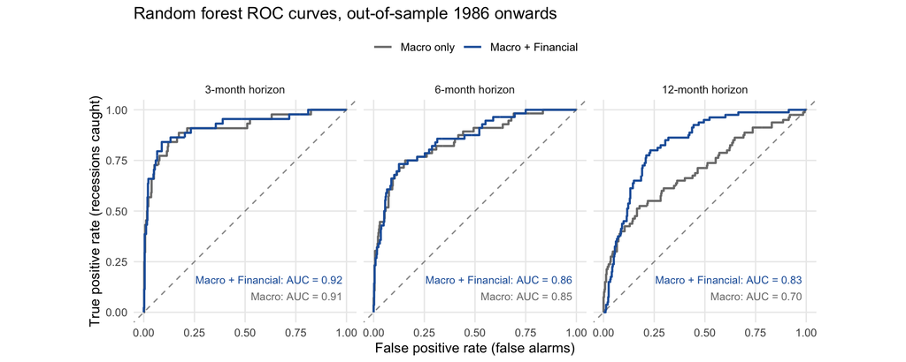

```r
roc_data <- rf_forecast_results %>%
  filter(model == "RF") %>%
  group_by(dataset, horizon) %>%
  group_modify(~ {
    r <- roc(.x$actual, .x$predicted_prob, levels = c(0, 1), direction = "<", quiet = TRUE)
    tibble(fpr = 1 - r$specificities,
           tpr = r$sensitivities,
           auc = as.numeric(auc(r)))
  }) %>%
  ungroup() %>%
  arrange(dataset, horizon, fpr, tpr)

# AUC labels for each panel
auc_labels <- roc_data %>%
  distinct(dataset, horizon, auc) %>%
  mutate(label = sprintf("%s: AUC = %.2f",
                         if_else(dataset == "Macro", "Macro", "Macro + Financial"), auc))

ggplot(roc_data, aes(x = fpr, y = tpr, colour = dataset)) +
  geom_abline(slope = 1, intercept = 0, linetype = "dashed", colour = "grey60") +
  geom_step(linewidth = 0.8) +
  geom_text(data = auc_labels,
            aes(x = 0.98, y = if_else(dataset == "Macro", 0.08, 0.16), label = label),
            hjust = 1, size = 3, show.legend = FALSE) +
  facet_wrap(~ horizon, labeller = labeller(horizon = function(h) paste0(h, "-month horizon"))) +
  scale_colour_manual(values = c(Macro = "#7A7A7A", Macro_Financial = "#1F5FA8"),
                      labels = c(Macro = "Macro only", Macro_Financial = "Macro + Financial")) +
  coord_equal() +
  labs(title = "Random forest ROC curves, out-of-sample 1986 onwards",
       x = "False positive rate (false alarms)", y = "True positive rate (recessions caught)",
       colour = NULL) +
  theme_minimal(base_size = 11) +
  theme(legend.position = "top", panel.grid.minor = element_blank())
```

## 6. Variable Importance

Permutation importance from RF model fitted on Macro + Financial data for all months with a known outcome. This is for interpretation only. It tells us which predictors the RF relies on most at each horizon.

```r
set.seed(1213)
fin_vars <- setdiff(names(macro_fin), names(macro))   # the 25 financial series
predictor_cols <- setdiff(names(macro_fin), c("sasdate", "USREC", "Y_3", "Y_6", "Y_12", "sample"))

importance_results <- bind_rows(lapply(c(3, 6, 12), function(h) {
  target <- paste0("Y_", h)
  d <- macro_fin %>% filter(!is.na(.data[[target]]))
  fit <- ranger(
    x = d[, predictor_cols],
    y = factor(d[[target]], levels = c(0, 1)),
    num.trees = 500,
    mtry = floor(sqrt(length(predictor_cols))),
    probability = TRUE,
    importance = "permutation"
  )
  tibble(horizon = h,
         variable = names(fit$variable.importance),
         importance = fit$variable.importance)
})) %>%
  mutate(group = if_else(variable %in% fin_vars, "Financial", "Macro"))

# Top 10 predictors per horizon
importance_results %>%
  group_by(horizon) %>%
  slice_max(importance, n = 10) %>%
  mutate(rank = row_number()) %>%
  ungroup() %>%
  print(n = Inf)
```

```
## # A tibble: 30 × 5
##    horizon variable  importance group      rank
##      <dbl> <chr>          <dbl> <chr>     <int>
##  1       3 TB6SMFFM     0.0125  Financial     1
##  2       3 TB3SMFFM     0.00949 Financial     2
##  3       3 USGOOD       0.00758 Macro         3
##  4       3 T1YFFM       0.00695 Financial     4
##  5       3 MANEMP       0.00687 Macro         5
##  6       3 PAYEMS       0.00647 Macro         6
##  7       3 DMANEMP      0.00635 Macro         7
##  8       3 NDMANEMP     0.00293 Macro         8
##  9       3 BAAFFM       0.00264 Financial     9
## 10       3 IPMANSICS    0.00261 Macro        10
## 11       6 TB6SMFFM     0.0146  Financial     1
## 12       6 TB3SMFFM     0.0142  Financial     2
```

[output cut: 18 more lines]

```r
# Share of total importance from financial vs macro predictors
importance_results %>%
  mutate(importance = pmax(importance, 0)) %>%
  group_by(horizon, group) %>%
  summarise(total = sum(importance), .groups = "drop_last") %>%
  mutate(share = total / sum(total)) %>%
  ungroup() %>%
  select(-total) %>%
  pivot_wider(names_from = group, values_from = share)
```

```
## # A tibble: 3 × 3
##   horizon Financial Macro
##     <dbl>     <dbl> <dbl>
## 1       3     0.396 0.604
## 2       6     0.524 0.476
## 3      12     0.646 0.354
```

## 7. Tuning mtry

Validation uses only pre-1986 data: forecasts for 1981–85 from an expanding window that starts in 1962, with targets rebuilt on the truncated data so no post-1985 outcome is used. The 1981–82 recession falls in this block.

```r
val_start <- as.Date("1981-01-01")

# Validation data: pre-1986 months only, with targets rebuilt so no post-1985 outcome is used
make_val_data <- function(df) {
  df %>%
    filter(sasdate < test_start) %>%
    select(-Y_3, -Y_6, -Y_12) %>%
    create_targets()
}

# Candidate mtry values between sqrt(p) and p
mtry_grid <- function(p) unique(c(floor(sqrt(p)), floor(2 * sqrt(p)), floor(p / 3), floor(p / 2), p))

set.seed(1213)
tuning_results <- list()

for (dataset_name in names(datasets)) {
  val_df <- make_val_data(datasets[[dataset_name]])
  p <- length(setdiff(names(val_df), c("sasdate", "USREC", "Y_3", "Y_6", "Y_12", "sample")))

  for (h in horizons) {
    for (m in mtry_grid(p)) {
      f <- forecast_rf(val_df, h, "RF", mtry = m, refit_every = 12, test_start = val_start)
      tuning_results[[paste(dataset_name, h, m, sep = "_")]] <- tibble(
        dataset = dataset_name, horizon = h, mtry = m,
        val_AUC = as.numeric(auc(f$actual, f$predicted_prob, quiet = TRUE))
      )
    }
  }
}

tuning_results <- bind_rows(tuning_results)
print(tuning_results, n = Inf)
```

```
## # A tibble: 30 × 4
##    dataset         horizon  mtry val_AUC
##    <chr>             <dbl> <dbl>   <dbl>
##  1 Macro                 3     9   0.972
##  2 Macro                 3    19   0.972
##  3 Macro                 3    32   0.964
##  4 Macro                 3    48   0.964
##  5 Macro                 3    97   0.957
##  6 Macro                 6     9   0.928
##  7 Macro                 6    19   0.916
##  8 Macro                 6    32   0.885
##  9 Macro                 6    48   0.890
## 10 Macro                 6    97   0.861
## 11 Macro                12     9   0.892
## 12 Macro                12    19   0.886
```

[output cut: 18 more lines]

```r
# Best mtry for each dataset x horizon
best_mtry <- tuning_results %>%
  group_by(dataset, horizon) %>%
  slice_max(val_AUC, n = 1, with_ties = FALSE) %>%
  ungroup()
best_mtry
```

```
## # A tibble: 6 × 4
##   dataset         horizon  mtry val_AUC
##   <chr>             <dbl> <dbl>   <dbl>
## 1 Macro                 3    19   0.972
## 2 Macro                 6     9   0.928
## 3 Macro                12     9   0.892
## 4 Macro_Financial       3   122   0.954
## 5 Macro_Financial       6    22   0.974
## 6 Macro_Financial      12    11   0.995
```

## 8. Extension: RF and Bagging with Selected Lagged Predictors

Same lag specification across models, so the extension is comparable. Lags are added after the targets are built, and the first 12 months are dropped so that every lag is observed.

### 8.1 Add lagged predictors

```r
lag_spec <- list(UNRATE   = c(3, 6),
                 PAYEMS   = c(3, 6),
                 CPIAUCSL = c(3, 6),
                 HOUST    = c(3, 6),
                 S_P_500  = c(3, 6),
                 T10YFFM  = c(6, 12))

# add lagged columns for the variables in each dataset
add_selected_lags <- function(df, lag_spec) {
  df <- df %>% arrange(sasdate)
  for (variable in names(lag_spec)) {
    if (!variable %in% names(df)) next
    for (k in lag_spec[[variable]]) {
      df[[paste0(variable, "_lag", k)]] <- lag(df[[variable]], k)
    }
  }
  df
}

macro_lagged     <- add_selected_lags(macro, lag_spec)
macro_fin_lagged <- add_selected_lags(macro_fin, lag_spec)

# drop the first 12 months, where longest lag is not yet observed
lag_start <- seq(min(macro$sasdate), by = "1 month", length.out = 13)[13]
macro_lagged     <- macro_lagged %>% filter(sasdate >= lag_start)
macro_fin_lagged <- macro_fin_lagged %>% filter(sasdate >= lag_start)

# checks: no missing predictors, and the number of predictors (p) in each set
excluded_cols <- c("sasdate", "USREC", "Y_3", "Y_6", "Y_12", "sample")
stopifnot(sum(is.na(macro_lagged[setdiff(names(macro_lagged), excluded_cols)])) == 0,
          sum(is.na(macro_fin_lagged[setdiff(names(macro_fin_lagged), excluded_cols)])) == 0)

c(p_macro_lagged     = length(setdiff(names(macro_lagged), excluded_cols)),
  p_macro_fin_lagged = length(setdiff(names(macro_fin_lagged), excluded_cols)))
```

```
##     p_macro_lagged p_macro_fin_lagged
##                105                134
```

### 8.2 Run all 12 lagged configurations

This uses the same function and settings as Section 4.

```r
datasets_lagged <- list(Macro = macro_lagged, Macro_Financial = macro_fin_lagged)

rf_file_lagged <- "../data/results/rf_forecasts_lagged.rds"

# load saved forecasts if exists, if not run every combination (delete the file to force a re-run)
if (file.exists(rf_file_lagged)) {
  rf_forecast_results_lagged <- readRDS(rf_file_lagged)
} else {
  all_forecasts_lagged <- list()

  for (dataset_name in names(datasets_lagged)) {
    for (h in horizons) {
      for (model_type in model_types) {
        cat("Running (lagged):", dataset_name, h, model_type, "\n")
        result <- forecast_rf(
          df = datasets_lagged[[dataset_name]],
          horizon = h,
          model_type = model_type
        )
        result$dataset <- dataset_name
        result$model <- model_type
        all_forecasts_lagged[[paste(dataset_name, h, model_type, sep = "_")]] <- result
      }
    }
  }

  rf_forecast_results_lagged <- bind_rows(all_forecasts_lagged)
  dir.create(dirname(rf_file_lagged), showWarnings = FALSE)
  saveRDS(rf_forecast_results_lagged, rf_file_lagged)
}

# verify that all 12 configurations ran, with the same test months as before
rf_forecast_results_lagged %>%
  group_by(dataset, horizon, model) %>%
  summarise(n_forecasts = n(), unique_dates = n_distinct(sasdate), .groups = "drop")
```

```
## # A tibble: 12 × 5
##    dataset         horizon model   n_forecasts unique_dates
##    <chr>             <dbl> <chr>         <int>        <int>
##  1 Macro                 3 Bagging         483          483
##  2 Macro                 3 RF              483          483
##  3 Macro                 6 Bagging         480          480
##  4 Macro                 6 RF              480          480
##  5 Macro                12 Bagging         474          474
##  6 Macro                12 RF              474          474
##  7 Macro_Financial       3 Bagging         483          483
##  8 Macro_Financial       3 RF              483          483
##  9 Macro_Financial       6 Bagging         480          480
## 10 Macro_Financial       6 RF              480          480
## 11 Macro_Financial      12 Bagging         474          474
## 12 Macro_Financial      12 RF              474          474
```

### 8.3 Evaluation and Macro vs Macro + Financial

```r
rf_evaluation_results_lagged <- rf_forecast_results_lagged %>%
  group_by(dataset, horizon, model) %>%
  group_modify(~ evaluate_forecasts(.x)) %>%
  ungroup()

print(rf_evaluation_results_lagged, n = Inf)
```

```
## # A tibble: 12 × 7
##    dataset         horizon model     AUC    F1 Balanced_Accuracy  Brier
##    <chr>             <dbl> <chr>   <dbl> <dbl>             <dbl>  <dbl>
##  1 Macro                 3 Bagging 0.876 0.589             0.792 0.0666
##  2 Macro                 3 RF      0.905 0.6               0.785 0.0582
##  3 Macro                 6 Bagging 0.832 0.527             0.758 0.0992
##  4 Macro                 6 RF      0.859 0.526             0.735 0.0868
##  5 Macro                12 Bagging 0.668 0.381             0.634 0.180
##  6 Macro                12 RF      0.715 0.411             0.650 0.155
##  7 Macro_Financial       3 Bagging 0.897 0.512             0.719 0.0645
##  8 Macro_Financial       3 RF      0.937 0.563             0.719 0.0481
##  9 Macro_Financial       6 Bagging 0.844 0.34              0.620 0.0933
## 10 Macro_Financial       6 RF      0.892 0.458             0.660 0.0717
## 11 Macro_Financial      12 Bagging 0.808 0.511             0.719 0.134
## 12 Macro_Financial      12 RF      0.860 0.507             0.697 0.110
```

```r
rf_financial_comparison_lagged <- rf_evaluation_results_lagged %>%
  pivot_wider(names_from = dataset,
              values_from = c(AUC, F1, Balanced_Accuracy, Brier)) %>%
  mutate(
    AUC_gain = AUC_Macro_Financial - AUC_Macro,
    F1_gain = F1_Macro_Financial - F1_Macro,
    Balanced_Accuracy_gain = Balanced_Accuracy_Macro_Financial - Balanced_Accuracy_Macro,
    Brier_improvement = Brier_Macro - Brier_Macro_Financial
  ) %>%
  select(horizon, model, AUC_gain, F1_gain, Balanced_Accuracy_gain, Brier_improvement) %>%
  arrange(model, horizon)

print(rf_financial_comparison_lagged, n = Inf)
```

```
## # A tibble: 6 × 6
##   horizon model   AUC_gain F1_gain Balanced_Accuracy_gain Brier_improvement
##     <dbl> <chr>      <dbl>   <dbl>                  <dbl>             <dbl>
## 1       3 Bagging   0.0213 -0.0773                -0.0727           0.00211
## 2       6 Bagging   0.0119 -0.187                 -0.138            0.00588
## 3      12 Bagging   0.140   0.130                  0.0854           0.0467
## 4       3 RF        0.0321 -0.0366                -0.0659           0.0101
## 5       6 RF        0.0333 -0.0685                -0.0746           0.0151
## 6      12 RF        0.146   0.0952                 0.0468           0.0445
```

### 8.4 Check if AUC gain is real (block bootstrap)

Same bootstrap as Section 5.3, applied to the lagged forecasts.

```r
set.seed(1213)
auc_gain_ci_lagged <- rf_forecast_results_lagged %>%
  select(sasdate, horizon, model, dataset, actual, predicted_prob) %>%
  pivot_wider(names_from = dataset, values_from = predicted_prob) %>%
  arrange(sasdate) %>%
  group_by(horizon, model) %>%
  group_modify(~ block_bootstrap_auc_gain(.x$actual, .x$Macro, .x$Macro_Financial)) %>%
  ungroup() %>%
  mutate(significant = CI_lower > 0 | CI_upper < 0) %>%
  arrange(model, horizon)

print(auc_gain_ci_lagged, n = Inf)
```

```
## # A tibble: 6 × 7
##   horizon model   AUC_gain CI_lower CI_upper valid_resamples significant
##     <dbl> <chr>      <dbl>    <dbl>    <dbl>           <int> <lgl>
## 1       3 Bagging   0.0213 -0.0640    0.136             1000 FALSE
## 2       6 Bagging   0.0119 -0.0698    0.102              999 FALSE
## 3      12 Bagging   0.140   0.0194    0.294             1000 TRUE
## 4       3 RF        0.0321  0.00196   0.0892             999 TRUE
## 5       6 RF        0.0333 -0.0131    0.0967             999 FALSE
## 6      12 RF        0.146   0.0367    0.306              999 TRUE
```

### 8.5 Check if adding lags improve performance

Compare the original and lagged forecasts on the same test months.

```r
paired_lag <- rf_forecast_results %>%
  select(sasdate, horizon, model, dataset, actual, prob_original = predicted_prob) %>%
  inner_join(
    rf_forecast_results_lagged %>%
      select(sasdate, horizon, model, dataset, actual, prob_lagged = predicted_prob),
    by = c("sasdate", "horizon", "model", "dataset", "actual")
  )

rf_lag_performance <- paired_lag %>%
  group_by(dataset, horizon, model) %>%
  group_modify(~ {
    original <- evaluate_forecasts(data.frame(actual = .x$actual, predicted_prob = .x$prob_original))
    lagged   <- evaluate_forecasts(data.frame(actual = .x$actual, predicted_prob = .x$prob_lagged))
    data.frame(
      n_paired = nrow(.x),
      AUC_original = original$AUC,
      AUC_lagged = lagged$AUC,
      AUC_change = lagged$AUC - original$AUC,
      Brier_original = original$Brier,
      Brier_lagged = lagged$Brier,
      Brier_improvement = original$Brier - lagged$Brier
    )
  }) %>%
  ungroup() %>%
  arrange(model, dataset, horizon)

print(rf_lag_performance, n = Inf)
```

```
## # A tibble: 12 × 10
##    dataset         horizon model   n_paired AUC_original AUC_lagged AUC_change
##    <chr>             <dbl> <chr>      <int>        <dbl>      <dbl>      <dbl>
##  1 Macro                 3 Bagging      483        0.881      0.876   -0.00525
##  2 Macro                 6 Bagging      480        0.831      0.832    0.00135
##  3 Macro                12 Bagging      474        0.660      0.668    0.00771
##  4 Macro_Financial       3 Bagging      483        0.891      0.897    0.00601
##  5 Macro_Financial       6 Bagging      480        0.800      0.844    0.0444
##  6 Macro_Financial      12 Bagging      474        0.780      0.808    0.0279
##  7 Macro                 3 RF           483        0.908      0.905   -0.00331
##  8 Macro                 6 RF           480        0.848      0.859    0.0104
##  9 Macro                12 RF           474        0.703      0.715    0.0117
## 10 Macro_Financial       3 RF           483        0.917      0.937    0.0199
## 11 Macro_Financial       6 RF           480        0.857      0.892    0.0349
## 12 Macro_Financial      12 RF           474        0.832      0.860    0.0286
## # ℹ 3 more variables: Brier_original <dbl>, Brier_lagged <dbl>,
## #   Brier_improvement <dbl>
```

### 8.6 Check if gain from adding lags is real (block bootstrap)

Same bootstrap as Section 5.3, comparing lagged against original forecasts on the same test months. `AUC_gain` here is AUC(lagged) − AUC(original).

```r
set.seed(1213)
lag_gain_ci <- paired_lag %>%
  arrange(sasdate) %>%
  group_by(dataset, horizon, model) %>%
  group_modify(~ block_bootstrap_auc_gain(.x$actual, .x$prob_original, .x$prob_lagged)) %>%
  ungroup() %>%
  rename(AUC_change = AUC_gain) %>%
  mutate(significant = CI_lower > 0 | CI_upper < 0) %>%
  arrange(model, dataset, horizon)

print(lag_gain_ci, n = Inf)
```

```
## # A tibble: 12 × 8
##    dataset         horizon model   AUC_change  CI_lower CI_upper valid_resamples
##    <chr>             <dbl> <chr>        <dbl>     <dbl>    <dbl>           <int>
##  1 Macro                 3 Bagging   -0.00525 -0.0163   0.00478             1000
##  2 Macro                 6 Bagging    0.00135 -0.00681  0.0100               999
##  3 Macro                12 Bagging    0.00771 -0.00937  0.0249              1000
##  4 Macro_Financial       3 Bagging    0.00601 -0.0435   0.107               1000
##  5 Macro_Financial       6 Bagging    0.0444  -0.0151   0.133               1000
##  6 Macro_Financial      12 Bagging    0.0279  -0.0460   0.0842              1000
##  7 Macro                 3 RF        -0.00331 -0.0111   0.000763             999
##  8 Macro                 6 RF         0.0104   0.000293 0.0226               999
##  9 Macro                12 RF         0.0117  -0.00329  0.0281               999
## 10 Macro_Financial       3 RF         0.0199   0.00116  0.0666               999
## 11 Macro_Financial       6 RF         0.0349   0.000262 0.0897               995
## 12 Macro_Financial      12 RF         0.0286   0.000501 0.0677              1000
## # ℹ 1 more variable: significant <lgl>
```

## 9. Random Forest vs Probit (12 months, Macro + Financial)

```r
# AUC with a fixed direction
auc_fixed <- function(y, p) {
  as.numeric(auc(roc(y, p, levels = c(0, 1), direction = "<", quiet = TRUE)))
}

# paired block bootstrap of AUC(model A) - AUC(model B) on the same months
bootstrap_auc_diff <- function(actual, prob_a, prob_b, block_length = 24, n_boot = 1000) {
  n <- length(actual)
  n_blocks <- ceiling(n / block_length)
  diffs <- replicate(n_boot, {
    starts <- sample(1:(n - block_length + 1), n_blocks, replace = TRUE)
    idx <- unlist(lapply(starts, function(s) s:(s + block_length - 1)))[1:n]
    y <- actual[idx]
    if (length(unique(y)) < 2) return(NA_real_)
    auc_fixed(y, prob_a[idx]) - auc_fixed(y, prob_b[idx])
  })
  data.frame(
    n_months = n,
    AUC_RF = auc_fixed(actual, prob_a),
    AUC_Probit = auc_fixed(actual, prob_b),
    AUC_diff = auc_fixed(actual, prob_a) - auc_fixed(actual, prob_b),
    CI_lower = unname(quantile(diffs, 0.025, na.rm = TRUE)),
    CI_upper = unname(quantile(diffs, 0.975, na.rm = TRUE)),
    valid_resamples = sum(!is.na(diffs))
  )
}

# 12-month, Macro + Financial forecasts for one RF run and one probit run, matched by date
compare_rf_probit <- function(rf_results, probit_results, label) {
  rf <- rf_results %>%
    filter(model == "RF", dataset == "Macro_Financial", horizon == 12) %>%
    select(sasdate, actual, prob_rf = predicted_prob)
  pr <- probit_results %>%
    filter(model == "Probit", dataset == "Macro_Financial", horizon == 12,
           is.finite(predicted_prob)) %>%
    select(sasdate, actual_probit = actual, prob_probit = predicted_prob)
  stopifnot(!anyDuplicated(pr$sasdate))
  paired <- inner_join(rf, pr, by = "sasdate") %>% arrange(sasdate)
  stopifnot(all(paired$actual == paired$actual_probit))   # same outcomes on matched months
  bootstrap_auc_diff(paired$actual, paired$prob_rf, paired$prob_probit) %>%
    mutate(comparison = label, .before = 1)
}

probit_results <- read_csv("../results/static_probit_logit_forecasts.csv", show_col_types = FALSE) %>%
  mutate(sasdate = as.Date(sasdate))

probit_lagged_file <- "../results/static_probit_logit_forecasts_lagged.csv"
if (!file.exists(probit_lagged_file)) {
  stop("Lagged probit forecasts not found: re-run baseline models.Rmd so it saves ", probit_lagged_file)
}
probit_results_lagged <- read_csv(probit_lagged_file, show_col_types = FALSE) %>%
  mutate(sasdate = as.Date(sasdate))

set.seed(1213)
rf_vs_probit <- bind_rows(
  compare_rf_probit(rf_forecast_results, probit_results, "RF vs Probit (original)"),
  compare_rf_probit(rf_forecast_results_lagged, probit_results_lagged, "RF lagged vs Probit lagged")
) %>%
  mutate(significant = CI_lower > 0 | CI_upper < 0)

print(rf_vs_probit, digits = 3)
```

```
##                   comparison n_months AUC_RF AUC_Probit AUC_diff CI_lower
## 1    RF vs Probit (original)      469  0.835      0.668    0.167    0.116
## 2 RF lagged vs Probit lagged      474  0.860      0.632    0.228    0.117
##   CI_upper valid_resamples significant
## 1    0.245            1000        TRUE
## 2    0.363            1000        TRUE
```